# Supplementary Material for Food-web complexity alters the fitness landscape of an insect herbivore

Matt Barbour

Load dataset. This dataset is a subset that only includes larva that survive to pupation or turned into parasitoids. We omitted any data where larva mortality was unclear. This enabled us to focus on the selection pressures imposed by insect parasitoids rather than other sources.

```r
## GAMM 1: models the effect of food-web treatment on univariate and multivariate fitness landscapes ----
GAMM_1 <- gamm.model(gall_survival ~
                       Treatment_contr.sum +
                       s(sc.gall_size, by=Treatment_contr.sum) +
                       s(sc.clutch_size, by=Treatment_contr.sum) +
                       s(sc.female_preference, by=Treatment_contr.sum) +
                       sc.gall_size:sc.clutch_size + sc.gall_size:sc.clutch_size:Treatment_contr.sum +
                       sc.gall_size:sc.female_preference + sc.gall_size:sc.female_preference:Treatment_contr.sum +                                sc.clutch_size:sc.female_preference + sc.clutch_size:sc.female_preference:Treatment_contr.sum,
                     data = gall_selection.df)
# summary(GAMM_1$gam); summary(GAMM_1$mer)

## GAMM 2: models the effect of food-web treatment on univariate, but not multivariate landscape ----
GAMM_2 <- gamm.model(gall_survival ~
                       Treatment_contr.sum +
                       s(sc.gall_size, by=Treatment_contr.sum) +
                       s(sc.clutch_size, by=Treatment_contr.sum) +
                       s(sc.female_preference, by=Treatment_contr.sum) +
                       sc.gall_size:sc.clutch_size +
                       sc.gall_size:sc.female_preference +
                       sc.clutch_size:sc.female_preference,
                     data = gall_selection.df)
# summary(GAMM_2$gam); summary(GAMM_2$mer)

## GAMM 3: models the effect of food-web treatment on univariate landscape ----
GAMM_3 <- gamm.model(gall_survival ~
                       Treatment_contr.sum +
                       s(sc.gall_size, by=Treatment_contr.sum) +
                       s(sc.clutch_size, by=Treatment_contr.sum) +
                       s(sc.female_preference, by=Treatment_contr.sum),
                      data = gall_selection.df)
# summary(GAMM_3$gam); summary(GAMM_3$mer)

## GAMM 4: assumes that the food-web does not modify the fitness landscape
GAMM_4 <- gamm.model(gall_survival ~
                       Treatment_contr.sum +
                       s(sc.gall_size) +
                       s(sc.clutch_size) +
                       s(sc.female_preference),
                     data = gall_selection.df)
# summary(GAMM_4$gam); summary(GAMM_4$mer)

## AIC Comparison of GAMMs
knitr::kable(AIC(GAMM_1$mer, GAMM_2$mer, GAMM_3$mer, GAMM_4$mer))
```

|  | df | AIC |
| --- | --- | --- |
| GAMM_1$mer | 23 | 1448.504 |
| GAMM_2$mer | 20 | 1442.961 |
| GAMM_3$mer | 17 | 1439.801 |
| GAMM_4$mer | 11 | 1438.671 |

Now let’s compare the best GAMMs to analog generalized linear mixed-models (GLMM). If these GLMMs have a lower AIC value than their respective GAMMs, then this suggests that there is only evidence of directional selection in our data.

```r
# Note that I still use gamm.model to allow for appropriate model comparisons

## GLMM 3: only models the effect of food-web treatment on directional selection gradients ----
GLMM_3 <- gamm.model(gall_survival ~
                       Treatment_contr.sum +
                       sc.gall_size + sc.gall_size:Treatment_contr.sum +
                       sc.clutch_size + sc.clutch_size:Treatment_contr.sum +
                       sc.female_preference + sc.female_preference:Treatment_contr.sum,
                      data = gall_selection.df)
#summary(GLMM_3$gam); summary(GLMM_3$mer)

## GLMM 4: only models the effect of food-web treatment on directional selection gradients ----
GLMM_4 <- gamm.model(gall_survival ~
                       Treatment_contr.sum +
                       sc.gall_size +
                       sc.clutch_size +
                       sc.female_preference,
                      data = gall_selection.df)
#summary(GLMM_4$gam); summary(GLMM_4$mer)

knitr::kable(AIC(GAMM_3$mer, GLMM_3$mer, GAMM_4$mer, GLMM_4$mer))
```

|  | df | AIC |
| --- | --- | --- |
| GAMM_3$mer | 17 | 1439.801 |
| GLMM_3$mer | 11 | 1428.433 |
| GAMM_4$mer | 11 | 1438.671 |
| GLMM_4$mer | 8 | 1432.655 |

It appears that the best predictive model is the GLMM that includes an effect of food-web treatment on directional selection gradients. Therefore, we continue by quantifying the effect of food-web treatment on directional selection gradients.

The model selection procedure was useful for pairing down the complexity of our model. To actually quantify the directional selection gradients in each treatment though, we analyze each treatment separately.

```r
# note that I've switched to using the lme4 package to analyzing the GLMM

# GLMM ----
glmer_control <- glmer(gall_survival ~ sc.gall_size + sc.clutch_size + sc.female_preference +
                           (1|Genotype/Plant_Position/Gall_Number),
                         data = control_df,
                         family = binomial(link = logit), optimizer = "bobyqa")
# summary(glmer_control)

# Mean fitness ----
Wbar_control <- inverse_logit(fixef(update(glmer_control, .~. -sc.gall_size -sc.clutch_size -sc.female_preference)))

# Confidence intervals for selection gradients ----
boot_Beta_control <- bootMer(glmer_control, FUN = Beta_avg_grad, nsim=100, parallel="multicore", ncpus=32)

## Summary ----
summary_Beta_glmm_control <- data.frame(
  Phenotype = c("Gall size", "Clutch size", "Female preference"),
  Food_Web = "Complex",
  Model = "GLMM",
  Beta = round(Beta_avg_grad(glmer_control),3),
  lower_2.5 = round(apply(boot_Beta_control$t, 2, FUN = function(bootstraps) quantile(bootstraps, 0.025)),3),
  upper_97.5 = round(apply(boot_Beta_control$t, 2, FUN = function(bootstraps) quantile(bootstraps, 0.975)),3))
```

```r
## GLMM ----
glmer_treatment <- glmer(gall_survival ~ sc.gall_size + sc.clutch_size + sc.female_preference +
                           (1|Genotype/Plant_Position/Gall_Number),
                         data = treatment_df,
                         family = binomial(link = logit), optimizer = "bobyqa")
# summary(glmer_treatment)

## Mean fitness ----
Wbar_treatment <- inverse_logit(fixef(update(glmer_treatment, .~. -sc.gall_size -sc.clutch_size -sc.female_preference)))
## Confidence intervals for selection gradients ----
boot_Beta_treatment <- bootMer(glmer_treatment, FUN = Beta_avg_grad, nsim=100, parallel="multicore", ncpus=32)
## Summary ----
summary_Beta_glmm_treatment <- data.frame(
  Phenotype = c("Gall size", "Clutch size", "Female preference"),
  Food_Web = "Simple",
  Model = "GLMM",
  Beta = round(Beta_avg_grad(glmer_treatment),2),
  lower_2.5 = round(apply(boot_Beta_treatment$t, 2, FUN = function(bootstraps) quantile(bootstraps, 0.025)),2),
  upper_97.5 = round(apply(boot_Beta_treatment$t, 2, FUN = function(bootstraps) quantile(bootstraps, 0.975)),2))
```

To ensure we are calculating these selection gradients correctly, we’ll compare our results to those obtained from the *gsg* package developed by Michael Morrissey.

```r
## GAMM Control ----
gamm_control <- gamm.model(gall_survival ~ sc.gall_size + sc.clutch_size + sc.female_preference,
                             data = control_df)
gsg_control <- data.frame(
  Phenotype = c("Gall size", "Clutch size", "Female preference"),
  Food_Web = "Complex",
  Model = "GAMM",
  Beta = round(c(gam.gradients(gamm_control$gam,
                         phenotype = "sc.gall_size", covariates = c("sc.clutch_size","sc.female_preference"),
                         se.method = "n")["B-sc.gall_size","estimates"],
           gam.gradients(gamm_control$gam,
                         phenotype = "sc.clutch_size", covariates = c("sc.gall_size","sc.female_preference"),
                         se.method = "n")["B-sc.clutch","estimates"],
           gam.gradients(gamm_control$gam,
                         phenotype = "sc.female_preference", covariates = c("sc.gall_size","sc.clutch_size"),
                         se.method = "n")["B-sc.female_preference","estimates"]),3),
  lower_2.5 = NA,
  upper_97.5 = NA)

## GAMM Treatment ----
gamm_treatment <- gamm.model(gall_survival ~ sc.gall_size + sc.clutch_size + sc.female_preference,
                             data = treatment_df)
gsg_treatment <- data.frame(
  Phenotype = c("Gall size", "Clutch size", "Female preference"),
  Food_Web = "Simple",
  Model = "GAMM",
  Beta = round(c(gam.gradients(gamm_treatment$gam,
                         phenotype = "sc.gall_size", covariates = c("sc.clutch_size","sc.female_preference"),
                         se.method = "n")["B-sc.gall_size","estimates"],
           gam.gradients(gamm_treatment$gam,
                         phenotype = "sc.clutch_size", covariates = c("sc.gall_size","sc.female_preference"),
                         se.method = "n")["B-sc.clutch","estimates"],
           gam.gradients(gamm_treatment$gam,
                         phenotype = "sc.female_preference", covariates = c("sc.gall_size","sc.clutch_size"),
                         se.method = "n")["B-sc.female_preference","estimates"]),3),
  lower_2.5 = NA,
  upper_97.5 = NA)

## Compare GAMM and GLMM estimates ----
compare_Beta <- bind_rows(gsg_control, gsg_treatment, summary_Beta_glmm_control, summary_Beta_glmm_treatment) %>%
  select(-lower_2.5, -upper_97.5) %>%
  spread(Model, Beta)
knitr::kable(compare_Beta)
```

| Phenotype | Food_Web | GAMM | GLMM |
| --- | --- | --- | --- |
| Clutch size | Complex | 0.036 | 0.036 |
| Clutch size | Simple | -0.123 | -0.100 |
| Female preference | Complex | 0.003 | 0.003 |
| Female preference | Simple | -0.245 | -0.200 |
| Gall size | Complex | 0.563 | 0.555 |
| Gall size | Simple | 0.347 | 0.290 |

The comparisons are quite close, but why should they differ at all? This suggests that my implementation of the Janzen and Stern 1998 method and Morrisey’s are slightly different. Perhaps this is because Janzen and Stern relies on the coefficient to calculate the gradient, whereas Morrisey calculates it using the finite difference methods for partial derivatives…

Now let’s look at how the confidence intervals vary between the GLMM and GAMMs. Note that I now fit it with a spline function to allow gsg to calculate bootstrap intervals (it won’t otherwise).

```r
## Fit generalized additive mixed models ----
gamm_control_2 <- gamm.model(gall_survival ~ s(sc.gall_size) + s(sc.clutch_size,k=9) + s(sc.female_preference),
                             data = control_df)

gamm_treatment_2 <- gamm.model(gall_survival ~ s(sc.gall_size) + s(sc.clutch_size,k=9) + s(sc.female_preference),
                             data = treatment_df)

## Estimate selection gradients ----
sg.size_control <- gradient.calc(mod = gamm_control_2$gam,
                                 phenotype = "sc.gall_size",
                                 covariates = c("sc.clutch_size","sc.female_preference"))
```

```
## Calculating bootstrap standard errors...
##       ... estimated completion at  2018-06-21 15:12:33 ...done.
```

```r
sg.size_treatment <- gradient.calc(mod = gamm_treatment_2$gam,
                                   phenotype = "sc.gall_size",
                                   covariates = c("sc.clutch_size","sc.female_preference"))
```

```
## Calculating bootstrap standard errors...
##       ... estimated completion at  2018-06-21 15:12:48 ...done.
```

```r
sg.clutch_control <- gradient.calc(mod = gamm_control_2$gam,
                                        phenotype = "sc.clutch_size",
                                        covariates = c("sc.gall_size","sc.female_preference"))
```

```
## Calculating bootstrap standard errors...
##       ... estimated completion at  2018-06-21 15:13:05 ...done.
```

```r
sg.clutch_treatment <- gradient.calc(mod = gamm_treatment_2$gam,
                                          phenotype = "sc.clutch_size",
                                          covariates = c("sc.gall_size","sc.female_preference"))
```

```
## Calculating bootstrap standard errors...
##       ... estimated completion at  2018-06-21 15:13:19 ...done.
```

```r
sg.preference_control <- gradient.calc(mod = gamm_control_2$gam,
                                    phenotype = "sc.female_preference",
                                    covariates = c("sc.clutch_size","sc.gall_size"))
```

```
## Calculating bootstrap standard errors...
##       ... estimated completion at  2018-06-21 15:13:35 ...done.
```

```r
sg.preference_treatment <- gradient.calc(mod = gamm_treatment_2$gam,
                                      phenotype = "sc.female_preference",
                                      covariates = c("sc.clutch_size","sc.gall_size"))
```

```
## Calculating bootstrap standard errors...
##       ... estimated completion at  2018-06-21 15:13:49 ...done.
```

```r
## Organize bootstrap estimates ----
bootstrap_df <- bind_rows(
  data.frame(Bootstrap_Estimates = sg.size_control$boot[ ,1],
             Phenotype = "Gall size", Selection_Type = "Beta", Food_Web = "Complex"),
  data.frame(Bootstrap_Estimates = sg.size_treatment$boot[ ,1],
             Phenotype = "Gall size", Selection_Type = "Beta", Food_Web = "Simple"),
  data.frame(Bootstrap_Estimates = sg.clutch_control$boot[ ,1],
             Phenotype = "Clutch size", Selection_Type = "Beta", Food_Web = "Complex"),
  data.frame(Bootstrap_Estimates = sg.clutch_treatment$boot[ ,1],
             Phenotype = "Clutch size", Selection_Type = "Beta", Food_Web = "Simple"),
  data.frame(Bootstrap_Estimates = sg.preference_control$boot[ ,1],
             Phenotype = "Female preference", Selection_Type = "Beta", Food_Web = "Complex"),
  data.frame(Bootstrap_Estimates = sg.preference_treatment$boot[ ,1],
             Phenotype = "Female preference", Selection_Type = "Beta", Food_Web = "Simple"))
## Summarise bootstrap estimates ----
gsg_gradients <- bootstrap_df %>%
  group_by(Phenotype, Food_Web) %>%
  summarise(Beta = round(mean(Bootstrap_Estimates),3),
            lower_2.5 = round(quantile(Bootstrap_Estimates, probs = 0.025),3),
            upper_97.5 = round(quantile(Bootstrap_Estimates, probs = 0.975),3)) %>%
  mutate(Model = "gsg_GAMM")

## Compare gsg GAMM and GLMM estimates of directional selection ----
bind_rows(gsg_gradients, summary_Beta_glmm_control, summary_Beta_glmm_treatment) %>%
  arrange(Phenotype, Food_Web, Model) %>%
  mutate(absolute_range = upper_97.5 - lower_2.5) %>%
  knitr::kable(.)
```

| Phenotype | Food_Web | Beta | lower_2.5 | upper_97.5 | Model | absolute_range |
| --- | --- | --- | --- | --- | --- | --- |
| Clutch size | Complex | 0.036 | -0.138 | 0.194 | GLMM | 0.332 |
| Clutch size | Complex | 0.039 | -0.032 | 0.112 | gsg_GAMM | 0.144 |
| Clutch size | Simple | -0.100 | -0.180 | 0.000 | GLMM | 0.180 |
| Clutch size | Simple | -0.124 | -0.171 | -0.079 | gsg_GAMM | 0.092 |
| Female preference | Complex | 0.003 | -0.182 | 0.216 | GLMM | 0.398 |
| Female preference | Complex | 0.004 | -0.075 | 0.086 | gsg_GAMM | 0.161 |
| Female preference | Simple | -0.200 | -0.280 | -0.090 | GLMM | 0.190 |
| Female preference | Simple | -0.245 | -0.283 | -0.205 | gsg_GAMM | 0.078 |
| Gall size | Complex | 0.555 | 0.440 | 0.653 | GLMM | 0.213 |
| Gall size | Complex | 0.563 | 0.499 | 0.627 | gsg_GAMM | 0.128 |
| Gall size | Simple | 0.290 | 0.190 | 0.340 | GLMM | 0.150 |
| Gall size | Simple | 0.349 | 0.303 | 0.397 | gsg_GAMM | 0.094 |

Both methods give the same qualitative results. However, range of the confidence intervals can be more than twice as large using my GLMM bootstrapping methods. Therefore, our reported intervals provide a conservative estimate.

```r
## Gather bootstrap data from GLMMs
glmm_boostrap_df <- bind_rows(
  data.frame(boot_Beta_treatment$t, ID = rep(1:dim(boot_Beta_treatment$t)[1]), Food_Web = "Simple"),
  data.frame(boot_Beta_control$t, ID = rep(1:dim(boot_Beta_control$t)[1]), Food_Web = "Complex")
)
## Gall size ----
select(glmm_boostrap_df, sc.gall_size, ID, Food_Web) %>%
  spread(Food_Web, sc.gall_size) %>%
  mutate(diff_gradient = Complex - Simple) %>%
  summarise(p_value = sum(diff_gradient < 0)/dim(glmm_boostrap_df)[1])
```

```
##   p_value
## 1       0
```

```r
## Clutch size ----
select(glmm_boostrap_df, sc.clutch_size, ID, Food_Web) %>%
  spread(Food_Web, sc.clutch_size) %>%
  mutate(diff_gradient = Complex - Simple) %>%
  summarise(p_value = sum(diff_gradient < 0)/dim(glmm_boostrap_df)[1])
```

```
##   p_value
## 1   0.045
```

```r
## Female preference ----
select(glmm_boostrap_df, sc.female_preference, ID, Food_Web) %>%
  spread(Food_Web, sc.female_preference) %>%
  mutate(diff_gradient = Complex - Simple) %>%
  summarise(p_value = sum(diff_gradient < 0)/dim(glmm_boostrap_df)[1])
```

```
##   p_value
## 1    0.01
```

```r
## Gall size ----
bootstrap_df %>%
  filter(Phenotype == "Gall size", Selection_Type == "Beta") %>%
  mutate(ID = rep(1:1000,2)) %>%
  spread(Food_Web, Bootstrap_Estimates) %>%
  mutate(diff_gradient = Complex - Simple) %>%
  summarise(p_value = sum(diff_gradient < 0)/1000)
```

```
##   p_value
## 1       0
```

```r
## Clutch size ----
bootstrap_df %>%
  filter(Phenotype == "Clutch size", Selection_Type == "Beta") %>%
  mutate(ID = rep(1:1000,2)) %>%
  spread(Food_Web, Bootstrap_Estimates) %>%
  mutate(diff_gradient = Complex - Simple) %>%
  summarise(p_value = sum(diff_gradient < 0)/1000)
```

```
##   p_value
## 1       0
```

```r
## Female preference ----
bootstrap_df %>%
  filter(Phenotype == "Female preference", Selection_Type == "Beta") %>%
  mutate(ID = rep(1:1000,2)) %>%
  spread(Food_Web, Bootstrap_Estimates) %>%
  mutate(diff_gradient = Complex - Simple) %>%
  summarise(p_value = sum(diff_gradient < 0)/1000)
```

```
##   p_value
## 1       0
```

Illustrating the relationship between phenotype and mean fitness depends critically on the range of parameters shown. Perhaps this is what it is a good idea to show it based on the actual phenotypic distributions, or for 1 +/- SD.

One interesting thing is that I don’t believe the relative fitness intervals correspond to the absolute fitness intervals. This is likely because there can be a high absolute fitness, but the relative fitness might not change all that much…This means I need to figure out another way to plot these intervals. One easy way to do this would be to just return a list of two data frames, one that corresponds to absolute fitness and the other to relative fitness. This would be the easiest solution that would also remove a lot of redundancy in my code.

Okay, I solved the interval problem with relative fitness. Now I want to see if I can smooth up the 95% interval plots, by just plotting these 95% bootstrapped reps, shouldn’t they be smooth lines? Is it something weird with geom_ribbon?

```r
## Gall size ----

# Control
RF_control_gall_size <- bootstrap_fitness(
  logistic_model = glmer_control,
  newdata = expand.grid(
     sc.gall_size = seq(-1,1,length.out=1000),
     sc.clutch_size = 0,
     sc.female_preference = 0),
  bootstraps=100)
```

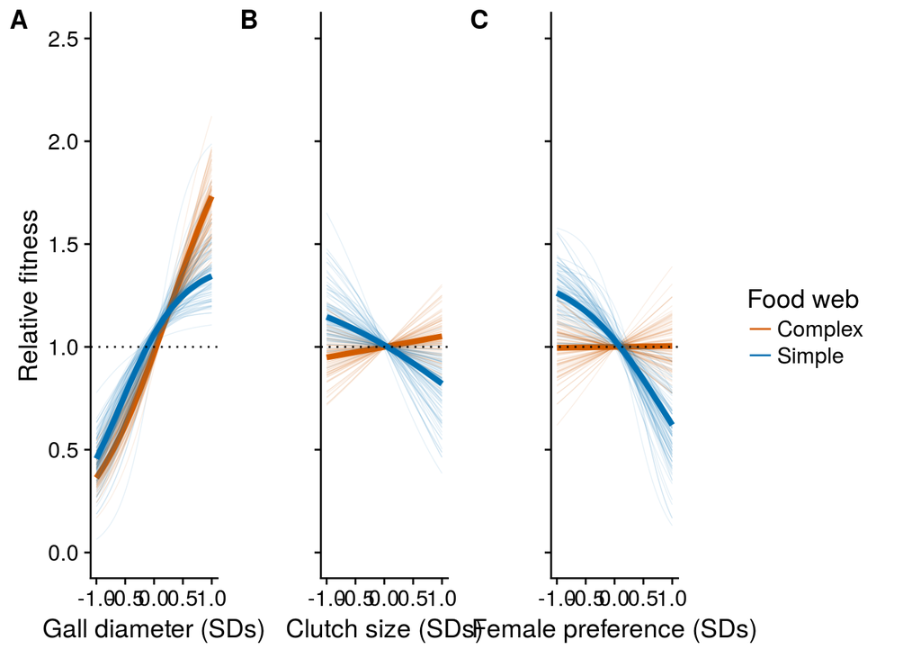

```r
# Treatment
RF_treatment_gall_size <- bootstrap_fitness(
  logistic_model = glmer_treatment,
  newdata = expand.grid(
     sc.gall_size = seq(-1,1,length.out=1000),
     sc.clutch_size = 0,
     sc.female_preference = 0),
  bootstraps=100)

## Clutch size ----

# Control
RF_control_clutch_size <- bootstrap_fitness(
  logistic_model = glmer_control,
  newdata = expand.grid(
     sc.gall_size = 0,
     sc.clutch_size = seq(-1,1,length.out=1000),
     sc.female_preference = 0),
  bootstraps=100)

# Treatment
RF_treatment_clutch_size <- bootstrap_fitness(
  logistic_model = glmer_treatment,
  newdata = expand.grid(
     sc.gall_size = 0,
     sc.clutch_size = seq(-1,1,length.out=1000),
     sc.female_preference = 0),
  bootstraps=100)

## Female preference ----

# Control
RF_control_female_preference <- bootstrap_fitness(
  logistic_model = glmer_control,
  newdata = expand.grid(
     sc.gall_size = 0,
     sc.clutch_size = 0,
     sc.female_preference = seq(-1,1,length.out=1000)),
  bootstraps=100)

# Treatment
RF_treatment_female_preference <- bootstrap_fitness(
  logistic_model = glmer_treatment,
  newdata = expand.grid(
     sc.gall_size = 0,
     sc.clutch_size = 0,
     sc.female_preference = seq(-1,1,length.out=1000)),
  bootstraps=100)

## Relative fitness plots ----

# Get range in relative fitness for accurate scaling across all plots
RF_gradient_range <- bind_rows(RF_treatment_gall_size$relative_fitness, RF_control_gall_size$relative_fitness,
          RF_treatment_clutch_size$relative_fitness, RF_control_clutch_size$relative_fitness,
          RF_treatment_female_preference$relative_fitness, RF_control_female_preference$relative_fitness) %>%
  select(-sc.clutch_size, -sc.female_preference) %>%
  gather(ID, relative_fitness, -sc.gall_size) %>%
  mutate(ID_group = ifelse(ID == "average", "average", "replicate")) %>%
  summarise(min = min(relative_fitness), max = max(relative_fitness))
RF_gradient_scale <- c(0,0.5,1,1.5,2,2.5) # adjusted based on range

# Color palette: order -> orange, light blue, green, yellow, dark blue, red, pink
cbPalette <- c("#E69F00", "#56B4E9", "#009E73", "#F0E442", "#0072B2", "#D55E00", "#CC79A7", "#000000", "#999999")
complex_color <- cbPalette[6]
simple_color <- cbPalette[5]
treatment_colors <- c(complex_color, simple_color)

# Gall size
RF_uni_size <- bind_rows(mutate(RF_treatment_gall_size$relative_fitness, Food_Web = "Simple"),
          mutate(RF_control_gall_size$relative_fitness, Food_Web = "Complex")) %>%
  select(-sc.clutch_size, -sc.female_preference) %>%
  gather(ID, relative_fitness, -sc.gall_size, -Food_Web) %>%
  mutate(ID_group = ifelse(ID == "average", "average", "replicate")) %>%
  ggplot(., aes(x=sc.gall_size, y=relative_fitness, group=interaction(ID,Food_Web), color=Food_Web, alpha=ID_group, size=ID_group)) +
  geom_line() +
  geom_hline(yintercept = 1, linetype = "dotted") +
  scale_alpha_manual(values=c(1,0.1), guide=FALSE) +
  scale_size_manual(values=c(1.5,0.25), guide=FALSE) +
  xlab("Gall diameter (SDs)") +
  ylab("Relative fitness") +
  scale_color_manual(values = treatment_colors, name = "Food web") +
  scale_y_continuous(breaks = RF_gradient_scale, limits = c(min(RF_gradient_scale), max(RF_gradient_scale)))

# Clutch size
RF_uni_clutch <- bind_rows(mutate(RF_treatment_clutch_size$relative_fitness, Food_Web = "Simple"),
          mutate(RF_control_clutch_size$relative_fitness, Food_Web = "Complex")) %>%
  select(-sc.gall_size, -sc.female_preference) %>%
  gather(ID, relative_fitness, -sc.clutch_size, -Food_Web) %>%
  mutate(ID_group = ifelse(ID == "average", "average", "replicate")) %>%
  ggplot(., aes(x=sc.clutch_size, y=relative_fitness, group=interaction(ID,Food_Web), color=Food_Web, alpha=ID_group, size=ID_group)) +
  geom_line() +
  geom_hline(yintercept = 1, linetype = "dotted") +
  scale_alpha_manual(values=c(1,0.1), guide=FALSE) +
  scale_size_manual(values=c(1.5,0.25), guide=FALSE) +
  xlab("Clutch size (SDs)") +
  ylab("Relative fitness") +
  scale_color_manual(values = treatment_colors, name = "Food web") +
  scale_y_continuous(breaks = RF_gradient_scale, limits = c(min(RF_gradient_scale), max(RF_gradient_scale)))


# Female preference
RF_uni_pref <- bind_rows(mutate(RF_treatment_female_preference$relative_fitness, Food_Web = "Simple"),
          mutate(RF_control_female_preference$relative_fitness, Food_Web = "Complex")) %>%
  select(-sc.gall_size, -sc.clutch_size) %>%
  gather(ID, relative_fitness, -sc.female_preference, -Food_Web) %>%
  mutate(ID_group = ifelse(ID == "average", "average", "replicate")) %>%
  ggplot(., aes(x=sc.female_preference, y=relative_fitness, group=interaction(ID,Food_Web), color=Food_Web, alpha=ID_group, size=ID_group)) +
  geom_line() +
  geom_hline(yintercept = 1, linetype = "dotted") +
  scale_alpha_manual(values=c(1,0.1), guide=FALSE) +
  scale_size_manual(values=c(1.5,0.25), guide=FALSE) +
  xlab("Female preference (SDs)") +
  ylab("Relative fitness") +
  scale_color_manual(values = treatment_colors, name = "Food web") +
  scale_y_continuous(breaks = RF_gradient_scale, limits = c(min(RF_gradient_scale), max(RF_gradient_scale)))

# Get legend
RF_uni_legend <- get_legend(RF_uni_size)

# Make plots
RF_uni_plots <- plot_grid(RF_uni_size + theme(legend.position = "none"),
                       RF_uni_clutch + theme(legend.position = "none",
                                          axis.title.y = element_blank(), axis.text.y = element_blank()),
                       RF_uni_pref + theme(legend.position = "none",
                                        axis.title.y = element_blank(), axis.text.y = element_blank()),
                       labels = "AUTO", ncol = 4, align='hv')

RF_gradients <- ggdraw(RF_uni_plots) + draw_grob(RF_uni_legend, x = 0.8, y=0)
RF_gradients
```

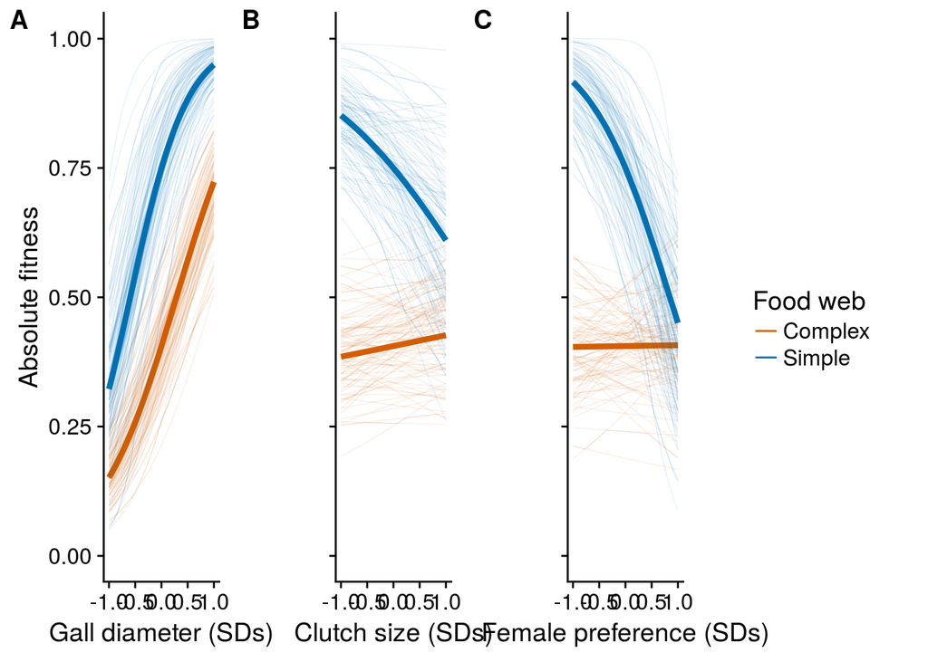

```r
#save_plot("RF_gradients.png", RF_gradients, base_height=6, base_width = 8)
#save_plot("RF_gradients.pdf", RF_gradients, base_height=6, base_width = 8)

## Absolute fitness plots ----

# Get range in relative fitness for accurate scaling across all plots
AF_gradient_scale <- c(0,0.25,0.5,0.75,1) # adjusted based on range

# Gall size
AF_uni_size <- bind_rows(mutate(RF_treatment_gall_size$absolute_fitness, Food_Web = "Simple"),
          mutate(RF_control_gall_size$absolute_fitness, Food_Web = "Complex")) %>%
  select(-sc.clutch_size, -sc.female_preference) %>%
  gather(ID, absolute_fitness, -sc.gall_size, -Food_Web) %>%
  mutate(ID_group = ifelse(ID == "average", "average", "replicate")) %>%
  ggplot(., aes(x=sc.gall_size, y=absolute_fitness, group=interaction(ID,Food_Web), color=Food_Web, alpha=ID_group, size=ID_group)) +
  geom_line() +
  scale_alpha_manual(values=c(1,0.1), guide=FALSE) +
  scale_size_manual(values=c(1.5,0.25), guide=FALSE) +
  xlab("Gall diameter (SDs)") +
  ylab("Absolute fitness") +
  scale_color_manual(values = treatment_colors, name = "Food web") +
  scale_y_continuous(breaks = AF_gradient_scale, limits = c(min(AF_gradient_scale), max(AF_gradient_scale)))

# Clutch size
AF_uni_clutch <- bind_rows(mutate(RF_treatment_clutch_size$absolute_fitness, Food_Web = "Simple"),
          mutate(RF_control_clutch_size$absolute_fitness, Food_Web = "Complex")) %>%
  select(-sc.gall_size, -sc.female_preference) %>%
  gather(ID, absolute_fitness, -sc.clutch_size, -Food_Web) %>%
  mutate(ID_group = ifelse(ID == "average", "average", "replicate")) %>%
  ggplot(., aes(x=sc.clutch_size, y=absolute_fitness, group=interaction(ID,Food_Web), color=Food_Web, alpha=ID_group, size=ID_group)) +
  geom_line() +
  scale_alpha_manual(values=c(1,0.1), guide=FALSE) +
  scale_size_manual(values=c(1.5,0.25), guide=FALSE) +
  xlab("Clutch size (SDs)") +
  ylab("Absolute fitness") +
  scale_color_manual(values = treatment_colors, name = "Food web") +
  scale_y_continuous(breaks = AF_gradient_scale, limits = c(min(AF_gradient_scale), max(AF_gradient_scale)))

# Female preference
AF_uni_pref <- bind_rows(mutate(RF_treatment_female_preference$absolute_fitness, Food_Web = "Simple"),
          mutate(RF_control_female_preference$absolute_fitness, Food_Web = "Complex")) %>%
  select(-sc.gall_size, -sc.clutch_size) %>%
  gather(ID, absolute_fitness, -sc.female_preference, -Food_Web) %>%
  mutate(ID_group = ifelse(ID == "average", "average", "replicate")) %>%
  ggplot(., aes(x=sc.female_preference, y=absolute_fitness, group=interaction(ID,Food_Web), color=Food_Web, alpha=ID_group, size=ID_group)) +
  geom_line() +
  scale_alpha_manual(values=c(1,0.1), guide=FALSE) +
  scale_size_manual(values=c(1.5,0.25), guide=FALSE) +
  xlab("Female preference (SDs)") +
  ylab("Absolute fitness") +
  scale_color_manual(values = treatment_colors, name = "Food web") +
  scale_y_continuous(breaks = AF_gradient_scale, limits = c(min(AF_gradient_scale), max(AF_gradient_scale)))

# Get legend
AF_uni_legend <- get_legend(AF_uni_size)

# Make plots
AF_uni_plots <- plot_grid(AF_uni_size + theme(legend.position = "none"),
                       AF_uni_clutch + theme(legend.position = "none",
                                          axis.title.y = element_blank(), axis.text.y = element_blank()),
                       AF_uni_pref + theme(legend.position = "none",
                                        axis.title.y = element_blank(), axis.text.y = element_blank()),
                       labels = "AUTO", ncol = 4, align='hv')

AF_gradients <- ggdraw(AF_uni_plots) + draw_grob(AF_uni_legend, x = 0.8, y=0)
AF_gradients
```

```r
#save_plot("AF_gradients.png", AF_gradients, base_height=6, base_width = 8)
#save_plot("AF_gradients.pdf", AF_gradients, base_height=6, base_width = 8)
```

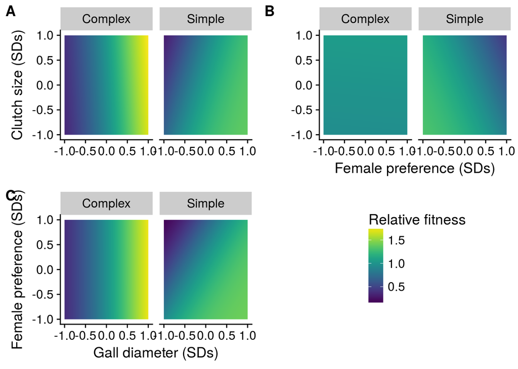

```r
## Clutch size x Female preference ----

# Control
RF_control_clutch.x.preference <- bootstrap_fitness(
  logistic_model = glmer_control,
  newdata = expand.grid(
     sc.gall_size = 0,
     sc.clutch_size = seq(-1,1,length.out=1000),
     sc.female_preference = seq(-1,1,length.out=1000)),
  bootstraps=NULL)

# Treatment
RF_treatment_clutch.x.preference <- bootstrap_fitness(
  logistic_model = glmer_treatment,
  newdata = expand.grid(
     sc.gall_size = 0,
     sc.clutch_size = seq(-1,1,length.out=1000),
     sc.female_preference = seq(-1,1,length.out=1000)),
  bootstraps=NULL)

## Gall size x Clutch size ----

# Control
RF_control_size.x.clutch <- bootstrap_fitness(
  logistic_model = glmer_control,
  newdata = expand.grid(
     sc.gall_size = seq(-1,1,length.out=1000),
     sc.clutch_size = seq(-1,1,length.out=1000),
     sc.female_preference = 0),
  bootstraps=NULL)

# Treatment
RF_treatment_size.x.clutch <- bootstrap_fitness(
  logistic_model = glmer_treatment,
  newdata = expand.grid(
     sc.gall_size = seq(-1,1,length.out=1000),
     sc.clutch_size = seq(-1,1,length.out=1000),
     sc.female_preference = 0),
  bootstraps=NULL)

## Gall size x Female preference ----

# Control
RF_control_size.x.preference <- bootstrap_fitness(
  logistic_model = glmer_control,
  newdata = expand.grid(
     sc.gall_size = seq(-1,1,length.out=1000),
     sc.clutch_size = 0,
     sc.female_preference = seq(-1,1,length.out=1000)),
  bootstraps=NULL)

# Treatment
RF_treatment_size.x.preference <- bootstrap_fitness(
  logistic_model = glmer_treatment,
  newdata = expand.grid(
     sc.gall_size = seq(-1,1,length.out=1000),
     sc.clutch_size = 0,
     sc.female_preference = seq(-1,1,length.out=1000)),
  bootstraps=NULL)

## Relative fitness plots ----

# Get range in relative fitness for accurate scaling across all plots
RF_range <- bind_rows(RF_treatment_clutch.x.preference$relative_fitness, RF_control_clutch.x.preference$relative_fitness,
          RF_treatment_size.x.clutch$relative_fitness, RF_control_size.x.clutch$relative_fitness,
          RF_treatment_size.x.preference$relative_fitness, RF_control_size.x.preference$relative_fitness) %>%
  summarise(min = min(average), max = max(average))

# Clutch x Preference
RF_plot_clutch.x.preference <- bind_rows(mutate(RF_treatment_clutch.x.preference$relative_fitness, Food_Web = "Simple"),
          mutate(RF_control_clutch.x.preference$relative_fitness, Food_Web = "Complex")) %>%
  ggplot(., aes(x=sc.female_preference, y=sc.clutch_size, fill=average)) +
  geom_raster() +
  facet_wrap(~Food_Web) +
  xlab("Female preference (SDs)") +
  ylab("Clutch size (SDs)") +
  #scale_fill_gradient2(midpoint=1, limits = c(RF_range$min, RF_range$max))
  scale_fill_viridis(limits = c(RF_range$min, RF_range$max), name = "Relative fitness")

# Size x Clutch
RF_plot_size.x.clutch <- bind_rows(mutate(RF_treatment_size.x.clutch$relative_fitness, Food_Web = "Simple"),
          mutate(RF_control_size.x.clutch$relative_fitness, Food_Web = "Complex")) %>%
  ggplot(., aes(x=sc.gall_size, y=sc.clutch_size, fill=average)) +
  geom_raster() +
  facet_wrap(~Food_Web) +
  xlab("Gall diameter (SDs)") +
  ylab("Clutch size (SDs)") +
  #scale_fill_gradient2(midpoint=1, limits = c(RF_range$min, RF_range$max))
  scale_fill_viridis(limits = c(RF_range$min, RF_range$max), name = "Relative fitness")

# Size x Preference
RF_plot_size.x.preference <- bind_rows(mutate(RF_treatment_size.x.preference$relative_fitness, Food_Web = "Simple"),
          mutate(RF_control_size.x.preference$relative_fitness, Food_Web = "Complex")) %>%
  ggplot(., aes(x=sc.gall_size, y=sc.female_preference, fill=average)) +
  geom_raster() +
  facet_wrap(~Food_Web) +
  xlab("Gall diameter (SDs)") +
  ylab("Female preference (SDs)") +
  #scale_fill_gradient2(midpoint=1, limits = c(RF_range$min, RF_range$max))
  scale_fill_viridis(limits = c(RF_range$min, RF_range$max), name = "Relative fitness")

# Get legend
RF_landscape_legend <- get_legend(RF_plot_size.x.preference)

# Format plots
RF_landscape_plots <- plot_grid(
  RF_plot_size.x.clutch + theme(legend.position = "none", axis.title.x = element_blank()),
  RF_plot_clutch.x.preference + theme(legend.position = "none", axis.title.y = element_blank()),
  RF_plot_size.x.preference + theme(legend.position = "none"),
  nrow=2, align="hv", labels = "AUTO")
RF_landscape_2d <- ggdraw(RF_landscape_plots) + draw_grob(RF_landscape_legend, x = 0.7, y=-0.2)
RF_landscape_2d
```

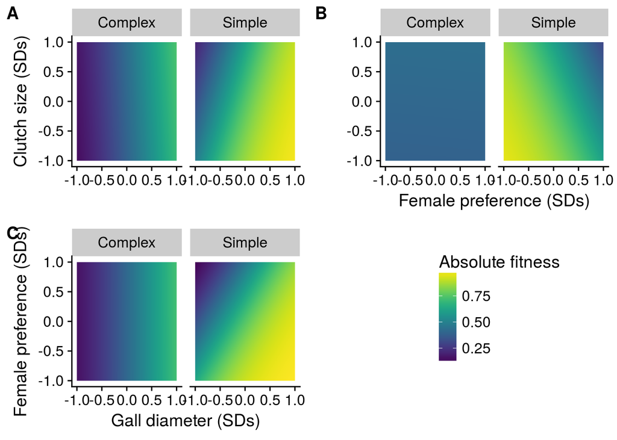

```r
#save_plot("RF_landscapes_2d.png", RF_landscape_2d, base_height=6, base_width = 8)
#save_plot("RF_landscapes_2d.pdf", RF_landscape_2d, base_height=6, base_width = 8)

## Absolute fitness landscapes ----
AF_range <- bind_rows(RF_treatment_clutch.x.preference$absolute_fitness, RF_control_clutch.x.preference$absolute_fitness,
          RF_treatment_size.x.clutch$absolute_fitness, RF_control_size.x.clutch$absolute_fitness,
          RF_treatment_size.x.preference$absolute_fitness, RF_control_size.x.preference$absolute_fitness) %>%
  summarise(min = min(average), max = max(average))

# Size x Preference
AF_plot_size.x.preference <- bind_rows(mutate(RF_treatment_size.x.preference$absolute_fitness, Food_Web = "Simple"),
          mutate(RF_control_size.x.preference$absolute_fitness, Food_Web = "Complex")) %>%
  ggplot(., aes(x=sc.gall_size, y=sc.female_preference, fill=average)) +
  geom_raster() +
  facet_wrap(~Food_Web) +
  xlab("Gall diameter (SDs)") +
  ylab("Female preference (SDs)") +
  scale_fill_viridis(limits = c(AF_range$min, AF_range$max), name = "Absolute fitness")

# Size x Clutch
AF_plot_size.x.clutch <- bind_rows(mutate(RF_treatment_size.x.clutch$absolute_fitness, Food_Web = "Simple"),
          mutate(RF_control_size.x.clutch$absolute_fitness, Food_Web = "Complex")) %>%
  ggplot(., aes(x=sc.gall_size, y=sc.clutch_size, fill=average)) +
  geom_raster() +
  facet_wrap(~Food_Web) +
  xlab("Gall diameter (SDs)") +
  ylab("Clutch size (SDs)") +
  scale_fill_viridis(limits = c(AF_range$min, AF_range$max), name = "Absolute fitness")

# Clutch x Preference
AF_plot_clutch.x.preference <- bind_rows(mutate(RF_treatment_clutch.x.preference$absolute_fitness, Food_Web = "Simple"),
          mutate(RF_control_clutch.x.preference$absolute_fitness, Food_Web = "Complex")) %>%
  ggplot(., aes(x=sc.female_preference, y=sc.clutch_size, fill=average)) +
  geom_raster() +
  facet_wrap(~Food_Web) +
  xlab("Female preference (SDs)") +
  ylab("Clutch size (SDs)") +
  scale_fill_viridis(limits = c(AF_range$min, AF_range$max), name = "Absolute fitness")

# Get legend
AF_landscape_legend <- get_legend(AF_plot_size.x.preference)

# Format plots
AF_landscape_plots <- plot_grid(
  AF_plot_size.x.clutch + theme(legend.position = "none", axis.title.x = element_blank()),
  AF_plot_clutch.x.preference + theme(legend.position = "none", axis.title.y = element_blank()),
  AF_plot_size.x.preference + theme(legend.position = "none"),
  nrow=2, align="hv", labels = "AUTO")
AF_landscape_2d <- ggdraw(AF_landscape_plots) + draw_grob(AF_landscape_legend, x = 0.7, y=-0.2)
AF_landscape_2d
```

```r
#save_plot("AF_landscapes_2d.png", AF_landscape_2d, base_height=6, base_width = 8)
#save_plot("AF_landscapes_2d.pdf", AF_landscape_2d, base_height=6, base_width = 8)
```

Parametric bootstrapping: Currently reported results

Case-wise bootstrapping: qualitative results match parametric bootstrapping.

Posterior: qualitative results match parametric bootstrapping, except that non-linear selection on gall size in the complex food-web is no longer significant.

Permutation: qualtiative results are consistent with parametric bootstrapping. Exceptions include: in the simple food-web, there is no evidence of non-linear selection for gall density or gall individuals. In the complex food-web, there is only marginal evidence for non-linear selection acting on gall size, but there is evidence for correlational selection between gall size and the number of individuals per gall.

Compare bootstrapped replicates across treatments, rather than comparing to zero.

Another decision we had to make was whether to calculate selection gradients with GAM or GAMMs. The problem with calculating selection gradients with GAMM is that the selection gradients can vary among environmental contexts that are being modelled by random intercepts. Since we did not alter random slopes, this would just cause variation in the selection gradients around the mean value, which is what our model tries to estimate. Therefore, we felt our GAMM model accurately reflects the selection that is happening at the population-level.

Now we plot the fitness landscapes associated with different combinations of gall phenotypes. We restrict these plots to 1 SD above and below the mean trait value, as this contains the majority of phenotypes under selection. Therefore, this fitness landscape integrates information from the fitness function with information about distributions of phenotype, and has been suggested to be a more informative way to visualize the magnitude of natural selection.